# Práticas em Bioinfo III

Prof. Heron OH

2023/01

Olá, esta é mais uma de um conjunto de práticas em bioinformática desenvolvidas para o curso de Biomedicina da PUC MG. Você pode encontrar as demais práticas [*aqui*](https://heronoh.github.io/bioinfo).

## *Scripts* bioinformáticos

Na prática passada você aprendeu a construir um *script* que desempenhava uma função simples, de saudação, utilizando funções/programas (outros *scripts*) existentes na linguagem *bash*. Da mesma maneira, é possível utilizar estes funções/programas para resolver os problemas de bioinformática que vimos nos exercícios, como a transformação de sequências de DNA em seu complemento reverso, em RNA, ou até mesmo em proteínas.

As ferramentas de *linha de comando* são especialmente eficientes para o processamento de informações de texto e tabelas. Assim, uma vez que a informação genética pode ser bem representada nesses tipos de arquivo, é possível aproveitar todo o poder dessas ferramentas, num contexto biológico.

Mas não é necessário que cada bioinformata faça seus próprios programas. À medida que o universo da bioinfo se desenvolve, as ferramentas mais eficientes e práticas acabam se estabelecendo e se difundindo, de maneira semelhante ao que ocorre no mundo da ciência.

Esta é a grande vantagem da (bio)informática. Por ser baseada (principalmente) em ferramentas de *código aberto*, qualquer pessoa pode fazer melhorias, reformulações, ou construir novas funções a partir das ferramentas existentes. E não é preciso *reinventar a roda!* Problemas clássicos, ou recorrentes, tendem a já possuir soluções disponíveis a alguns cliques de distância.

### Tradução: o ribossomo digital

Figura central no funcionamento celular e no fluxo da informação biológica, o **ribossomo** é uma máquina perfeita, modelada pela seleção natural. Como um computador na célula, ele é capaz de decodificar a traduzir a informação contida no *RNA mensagiro* (mRNA) em uma sequência correspondente de *amino ácidos*, produzindo as *proteínas* que desempenham as mais diversas atividades.

Reproduzir um *ribossomo* no mundo virtual é relativamente simples: basta escrever um *script* que, para cada trinca de letras de um arquivo *.fasta* (representando 3 nucleotídeos do *DNA/mRNA*), identifique uma letra (representando um *amino ácido*, ou um *sinal de parada*, correspondentes). Este *script* precisaria conter um dicionário, com todas as correspondências entre as trincas de nucleotídeos e cada *amino ácido*, utilizando letras como representações, como o [código sequências biológicas da **IUPAC**](https://www.bioinformatics.org/sms/iupac.html) (a *International Union of Pure and Applied Chemistry*).

#### Baixando um tradutor

A partir de uma busca rápida no [*Google*](https://www.google.com/), com as palavras chave “*DNA protein translate command line*”, você observará que há muitas opções pacotes e programas. Um programa de tradução de **DNA|proteína** muito utilizado é o *transeq*, do pacote [**EMBOSS**](http://emboss.open-bio.org/) (o *European Molecular Biology Open Software Suite*). Este é um pacote que reúne [dezenas de programas](https://www.bioinformatics.nl/emboss-explorer/) para trabalhar com arquivos de sequências e outros arquivos comuns na bioinformática. Ele foi desenvolvido em conjunto, por pesquisadores de diferentes centros de pesquisa como o [**EMBL-EBI**](https://www.ebi.ac.uk/about), o [**WSI**](https://www.sanger.ac.uk/), o [**BBSRC**](https://www.ukri.org/councils/bbsrc/) e o [**MRC**](https://www.mrc-bsu.cam.ac.uk/). O pacote **EMBOSS** pode ser instalado de maneira semelhante a qualquer aplicativo da distribuição de *Linux* que estamos usando (**Ubuntu - Debian**), com o *sistema de gerenciamento de pacotes* **apt**.

> Instale o pacote **EMBOSS** utilizando o *sistema de gerenciamento de pacotes* **apt**.

```bash
sudo apt install emboss
```

> Após a instalação, verifique que agora você possui a ferramenta/*script* *transeq*, e abra seu manual.

```bash
transeq --help
```

#### Traduzindo um arquivo *.fasta*

Antes de começar, vamos organizar uma pasta para trabalhar com os arquivos desta prática.

> Na sua *home*, crie uma pasta *aula3* para os arquivos da prática de hoje. Entre nesta pasta.

```bash
cd

mkdir aula3

cd aula3
```

Agora, vamos criar o arquivo que utilizaremos. Vamos trabalhar com a sequência do gene [*Citocromo C Oxidase I*](https://en.wikipedia.org/wiki/Cytochrome_c_oxidase_subunit_I), um gene que codifica uma das proteínas da *Cadeia transportadora de elétrons* da *fosforilação oxidativa*, responsável pela respiração celular, na mitocôndria.

```bash
vi mtCOI.fasta
```

> Cole o conteúdo a seguir dentro do seu arquivo no editor de textos *vi*. Depois salve o conteúdo e saia.

```bash
>NC_012920.1:5904-7445 Homo sapiens mitochondrion, complete genome
ATGTTCGCCGACCGTTGACTATTCTCTACAAACCACAAAGACATTGGAACACTATACCTATTATTCGGCG
CATGAGCTGGAGTCCTAGGCACAGCTCTAAGCCTCCTTATTCGAGCCGAGCTGGGCCAGCCAGGCAACCT
TCTAGGTAACGACCACATCTACAACGTTATCGTCACAGCCCATGCATTTGTAATAATCTTCTTCATAGTA
ATACCCATCATAATCGGAGGCTTTGGCAACTGACTAGTTCCCCTAATAATCGGTGCCCCCGATATGGCGT
TTCCCCGCATAAACAACATAAGCTTCTGACTCTTACCTCCCTCTCTCCTACTCCTGCTCGCATCTGCTAT
AGTGGAGGCCGGAGCAGGAACAGGTTGAACAGTCTACCCTCCCTTAGCAGGGAACTACTCCCACCCTGGA
GCCTCCGTAGACCTAACCATCTTCTCCTTACACCTAGCAGGTGTCTCCTCTATCTTAGGGGCCATCAATT
TCATCACAACAATTATCAATATAAAACCCCCTGCCATAACCCAATACCAAACGCCCCTCTTCGTCTGATC
CGTCCTAATCACAGCAGTCCTACTTCTCCTATCTCTCCCAGTCCTAGCTGCTGGCATCACTATACTACTA
ACAGACCGCAACCTCAACACCACCTTCTTCGACCCCGCCGGAGGAGGAGACCCCATTCTATACCAACACC
TATTCTGATTTTTCGGTCACCCTGAAGTTTATATTCTTATCCTACCAGGCTTCGGAATAATCTCCCATAT
TGTAACTTACTACTCCGGAAAAAAAGAACCATTTGGATACATAGGTATGGTCTGAGCTATGATATCAATT
GGCTTCCTAGGGTTTATCGTGTGAGCACACCATATATTTACAGTAGGAATAGACGTAGACACACGAGCAT
ATTTCACCTCCGCTACCATAATCATCGCTATCCCCACCGGCGTCAAAGTATTTAGCTGACTCGCCACACT
CCACGGAAGCAATATGAAATGATCTGCTGCAGTGCTCTGAGCCCTAGGATTCATCTTTCTTTTCACCGTA
GGTGGCCTGACTGGCATTGTATTAGCAAACTCATCACTAGACATCGTACTACACGACACGTACTACGTTG
TAGCCCACTTCCACTATGTCCTATCAATAGGAGCTGTATTTGCCATCATAGGAGGCTTCATTCACTGATT
TCCCCTATTCTCAGGCTACACCCTAGACCAAACCTACGCCAAAATCCATTTCACTATCATATTCATCGGC
GTAAATCTAACTTTCTTCCCACAACACTTTCTCGGCCTATCCGGAATGCCCCGACGTTACTCGGACTACC
CCGATGCATACACCACATGAAACATCCTATCATCTGTAGGCTCATTCATTTCTCTAACAGCAGTAATATT
AATAATTTTCATGATTTGAGAAGCCTTCGCTTCGAAGCGAAAAGTCCTAATAGTAGAAGAACCCTCCATA
AACCTGGAGTGACTATATGGATGCCCCCCACCCTACCACACATTCGAAGAACCCGTATACATAAAATCTA
GA
```

> Verifique o conteúdo do arquivo que você criou:

```bash
cat mtCOI.fasta
```

Agora, vamos traduzir essa proteína utilizando a função recém-instalada, *transeq*.

> Traduza a sequência do arquivo mtCOI.fasta para o arquivo mtCOI.pep.

```bash
transeq mtCOI.fasta
```

Observe que o programa te perguntou, interativamente, qual nome ele deveria dar ao arquivo de *output*. Isto poderia ser evitado caso você fornecesse o nome desse arquivo como argumento *-outseq $nome-do-arquivo-de-saída*.

Agora, vamos ver o conteúdo do arquivo gerado.

> Liste os arquivos e visualize o contaúdo do arquivo gerado pelo *transeq*.

```bash
ls

cat mtCOI.pep
```

**Atenção!** Observe que há algo de estranho na sequência gerada. Note que o símbolo * aparece algumas vezes em meio à sequência de letras que representa os amino ácidos. Esse símbolo, em *arquivos fasta de amino ácidos* representa **códons de parada***, os códons que dizem para o ribossomo que a tradução daquela proteína terminou.

Mas, sendo o COI uma proteína única e sem íntrons, estes *códons de parada* não deveriam estar presentes no meio de sua sequência. Para tentarmos entender melhor, vamos usar um recurso externo.

#### Trabalhando na internet

Muitos programas de bioinformática, especialmente os mais utilizados, apresentam versões *online*, e são hospedados em *sites* onde qualquer pessoa pode ter acesso aos seus recursos. Em última análise, esses programas estão realizando as mesmas operações que quando são rodados no seu próprio computador, mas nesse caso o seu processamento é feito por sevidores remotos (em outro local).

Para a *tradução de arquivos de sequências biológicas*, um serviço online muito bom e muito utilizado é o [*Expasy translate tool*](https://web.expasy.org/translate/), mantido pelo **SBI** (*Swiss Institute of Bioinformatics*). Vamos realizar a tradução da nossa sequência utilizando esse serviço.

> Acesse o site da ferramenta [Expasy translate tool](https://web.expasy.org/translate/).

> Cole a sequência do arquivo mtCOI.fasta na caixa de texto para tradução, com ou sem o cabeçalho (>).

> Acione o botão *Translate*, utilizando os parâmetros *default*.

Veja que obtivemos um resultado semelhante, porém mais completo. Agora, temos 6 possibilidades de tradução, que correspondem a 3 fases de leitura (*ORFs* - [*Open Reading Frames*](https://pt.wikipedia.org/wiki/Fase_de_leitura_aberta)) para cada uma das duas fitas, a *fita codificadora* e a *fita complementar*.

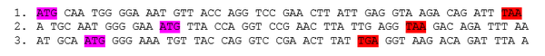

Isso acontece porquê o local de início da tradução pelo ribossomo não é exato, mas sim definido pela própria composição da sequência, em funções de sinais como o primeiro *códon de iniciação*, que também corresponde à incorporação do amino ácido **metionina** (representado por *M*, ou *Met*). Ou seja, todas as protéinas tem sua síntese iniciada por uma **metionina** (em eucariotos e *archea*; e por fenil-metionina (*fMet*) em bactérias, mitocôndrias e plastídeos).

Agora, vamos entender os nossos resultados. Na página gerada pelo *Expasy translate tool*, observe que há um campo **Genetic code** que está definido como *Standard*. Veja as outras opções disponíveis. Vamos avaliar outras possivilidades. Lembre-se que: *o gene COI é um gene mitocondrial*.

> Altere o **Genetic code** de *Standard* para *Vertebrate mitochondrial*. Acione o botão *Translate* novamente.

Veja que agora temos um resultado mais pertinente com a realidade! O primeiro resultado (correspondente à *fita codificadora* em sua *primeira fase de leitura*) apresenta uma proteína completa, iniciada por uma metionina, e finalizada por um códon de parada!

Ou seja, o nosso resultado estava errado pois estávamos utilizando o *código genético* (o *dicionário*) errado! Os nossos ribossomos e os ribossomos de nossas mitocôndrias utilizam códigos ligeiramente diferentes.

Este é um exemplo de que, quando um *script*/programa/código funciona, não significa que ele gerou um resultado correto, biológicamente pertininete. A expertise do bioinformata esta justamente em compreender o que o o computador executou, avaliar se o resultado faz sentido e, caso não, entender o que precisa ser modificado para o funcionamento adequado.

## Exercícios

> Utilizando a ferramenta *transeq*, refaça a tradução da sequência do arquivo mtCOI.fasta. Lembre-se de explorar as possibilidades de configuração com o argumento *–help*.

> Visualize o arquivo gerado e confira se o resultado esperado foi obtido.

> > > > Voltar para a [*página inicial*](https://heronoh.github.io/bioinfo)